# Ancient Chinese characters

### Transform the image data for NN training and testing

- Create 4D input arrays, containing a single color channel as the 4th dimension.
- Convert character class and era into 1-hot output vector.

```python
from sklearn import preprocessing
import keras

# input image dimensions
img_x, img_y = X_train.shape[1], X_train.shape[2]

# reshape the data into a 4D tensor - (sample_number, x_img_size, y_img_size, num_channels)
# because the images are greyscale, we only have a single channel - RGB colour images would have 3
X_train_rs_orig = X_train.reshape(X_train.shape[0], img_x, img_y, 1)
X_test_rs_orig = X_test.reshape(X_test.shape[0], img_x, img_y, 1)
input_shape = (img_x, img_y, 1)

# convert text class labels into index numbers
classnames = np.unique(y_train)
le = preprocessing.LabelEncoder().fit(classnames)
y_train_int = le.transform(y_train)
y_test_int = le.transform(y_test)

# convert class vectors to binary class matrices - this is for use in the
# categorical_crossentropy loss below
num_classes = np.unique(y_train).shape[0]
y_train_bin = keras.utils.to_categorical(y_train_int, num_classes)
y_test_bin = keras.utils.to_categorical(y_test_int, num_classes)
```

### Modify training images during training

Durint training, this is called to randomly shift and/or rotate training images to help the network learn to generalize better.

```python
import PIL
from random import random

def modify_images(images,
                  rotate=0, shift=[0,0],
                  stretch=[0,0], skew=[0,0]):
    """Modify images by shifting anr/or rotating them"""

    modimages = images.copy()

#     print('modimages.shape',modimages.shape)

    for image in modimages:
#         print('image.shape',image.shape)
        pim = PIL.Image.fromarray(image[:,:,0])

        if rotate > 0:
            pim = pim.rotate(random() * rotate*2 - rotate)

        if shift[0] > 0:
            pim = PIL.ImageChops.offset(pim,
                    int(random()*shift[0]*2-shift[0]),
                    int(random()*shift[1]*2-shift[1]))

        image[:,:,0] = np.asarray(pim).astype(int)

    return modimages
```

### Create convolutional neural net

Based in part on code from:

- [Keras tutorial – build a convolutional neural network in 11 lines](http://adventuresinmachinelearning.com/keras-tutorial-cnn-11-lines/)
- [Tutorial code](https://github.com/adventuresinML/adventures-in-ml-code/blob/master/keras_cnn.py)

#### Model layer structure:

- Convolution X 64
- Dropout
- Max pooling
- Convolution X 128
- Dropout
- Max pooling
- Dense X 1000
- Dropout
- Output

#### image modification during training:

- Model training is iterated for several epochs, then the training images are rotated and shifted randomly. This helps the model generalize (based on tests done in a different notebooks script).

```python
import keras
from keras.layers import Dense, Flatten, Dropout
from keras.layers import Conv2D, MaxPooling2D
from keras.models import Sequential

dropoutrate = .4
# convlayersize = [32, 64]
convlayersize = [64, 128]

adddropout = True

model = Sequential()
model.add(Conv2D(convlayersize[0], kernel_size=(5, 5), strides=(1, 1),
                 activation='relu',
                 input_shape=input_shape))
if adddropout:
    model.add(Dropout(dropoutrate))
model.add(MaxPooling2D(pool_size=(2, 2), strides=(2, 2)))
model.add(Conv2D(convlayersize[1], (5, 5), activation='relu'))
if adddropout:
    model.add(Dropout(dropoutrate))
model.add(MaxPooling2D(pool_size=(2, 2)))
model.add(Flatten())
model.add(Dense(1000, activation='relu'))
if adddropout:
    model.add(Dropout(dropoutrate))
model.add(Dense(num_classes, activation='softmax'))

# model.compile(loss='categorical_crossentropy',
model.compile(loss='mean_squared_error',
              optimizer=keras.optimizers.Adam(),
              metrics=['accuracy'])

print(model.summary())
```

```
_________________________________________________________________
Layer (type)                 Output Shape              Param #
=================================================================
conv2d_1 (Conv2D)            (None, 101, 115, 64)      1664
_________________________________________________________________
dropout_1 (Dropout)          (None, 101, 115, 64)      0
_________________________________________________________________
max_pooling2d_1 (MaxPooling2 (None, 50, 57, 64)        0
_________________________________________________________________
conv2d_2 (Conv2D)            (None, 46, 53, 128)       204928
_________________________________________________________________
dropout_2 (Dropout)          (None, 46, 53, 128)       0
_________________________________________________________________
max_pooling2d_2 (MaxPooling2 (None, 23, 26, 128)       0
_________________________________________________________________
flatten_1 (Flatten)          (None, 76544)             0
_________________________________________________________________
dense_1 (Dense)              (None, 1000)              76545000
_________________________________________________________________
dropout_3 (Dropout)          (None, 1000)              0
_________________________________________________________________
dense_2 (Dense)              (None, 377)               377377
=================================================================
Total params: 77,128,969
Trainable params: 77,128,969
Non-trainable params: 0
_________________________________________________________________
None
```

### Callback function to display performance stats during training

```python
from keras.callbacks import Callback
from IPython.display import clear_output

# Fancy updating plot callback with loss and accuracy

class PlotLearning(Callback):

    # ***********************************************
    def __init__(self, numepochs=0, numsamps=0,
                 batchsize=0, updaterate=1, figsize=(15,5)):
        self.numepochs = numepochs
        self.numsamps = numsamps
        self.batchsize = batchsize
        self.updaterate = updaterate
        self.figsize = figsize

    # ***********************************************
    def on_train_begin(self, logs={}):
        self.i = 0
        self.x = []
        self.valx = []
        self.losses = []
        self.val_losses = []
        self.acc = []
        self.val_acc = []
        self.logs = []
        self.batchnum = 0
        self.epochnum = 0

        self.t0 = time()

        self.batchperepoch = (int(self.numsamps/self.batchsize) +
            int(self.numsamps%self.batchsize > 0) )

        self.fig = plt.figure();

    # ***********************************************
    def plot_log_output(self):
        f, (ax1, ax2, ax3) = plt.subplots(1, 3, figsize=self.figsize);
        clear_output(wait=True)
        plt.suptitle('epoch %d / %d, batch %d / %d'%(self.epochnum+1, self.numepochs,
                                                self.batchnum+1, self.batchperepoch))
        ax1.set_yscale('log')
#             ax1.set_ylim(bottom=0)
        ax1.set_title('loss')
        ax1.plot(self.x, self.losses, 'r-', label="loss = %1.3f"%(self.losses[-1]))
        if len(self.val_losses) > 0:
            ax1.plot(self.valx, self.val_losses, 'b-x',
                     label="validation loss = %1.3f"%(self.val_losses[-1]))
        ax1.legend()

        ax2.set_title('accuracy')
        ax2.set_ylim(bottom=0)
        ax2.plot(self.x, self.acc, 'r-', label="accuracy = %1.3f"%(self.acc[-1]))
        if len(self.val_acc) > 0:
            ax2.plot(self.valx, self.val_acc, 'b-x', label="validation accuracy = %1.3f"%(self.val_acc[-1]))
        ax2.legend()

        detailtext = ''
        for layer,i in zip(self.model.layers, range(len(self.model.layers))):
            cfg = layer.get_config()
            if 'units' in cfg.keys():
                detailtext += '  %s: %d units, %s\n'%(
                    cfg['name'], cfg['units'], cfg['activation'])
            else:
                detailtext += '  %s\n'%(cfg['name'])

        ax3.set_title('model details')
        ax3.set_xlim([0, 10])
        ax3.set_ylim([0, 10])
        ax3.text(0,9,detailtext, ha='left',va='top')
        ax3.axis('off')

        plt.show();

    # ***********************************************
    def on_batch_end(self, batch, logs={}):
        self.logs.append(logs)
        self.x.append(self.i)
        self.losses.append(logs.get('loss'))
        self.acc.append(logs.get('acc'))
        self.i += 1
        self.batchnum = batch

        # use timing to decide when to plot
#         if self.i % self.batchperupdate == 0:
        if time() - self.t0 >= self.updaterate:
            self.plot_log_output()
            self.t0 = time()

    # ***********************************************
    def on_epoch_begin(self, epoch, logs={}):
        self.epochnum = epoch
        self.batchnum = 0
        self.t0 = time()

    # ***********************************************
    def on_epoch_end(self, epoch, logs={}):
        self.logs.append(logs)
        self.x.append(self.i)
        self.losses.append(logs.get('loss'))
        self.acc.append(logs.get('acc'))
        if 'val_loss' and 'val_acc' in logs:
            self.val_losses.append(logs.get('val_loss'))
            self.val_acc.append(logs.get('val_acc'))
            self.valx.append(self.i)
        self.i += 1
#         self.plot_log_output()
```

### Train the model

- Iterate training several times
- Every time rotate and shift every image randomly so that no two images are exactly the same

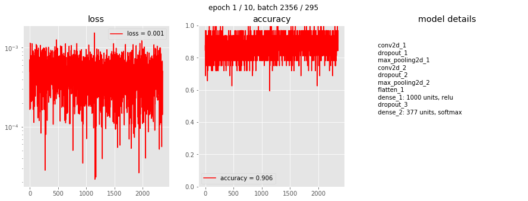

```python
from keras.callbacks import EarlyStopping
from time import time

t0 = time()

rotate=20
shift=[10,10]
stretch=[0,0]
skew=[0,0]

batch_size = 256
epochs = 10
updaterate = 5

plot_losses = PlotLearning(numepochs=epochs,
                           numsamps=X_train_rs_orig.shape[0],
                           batchsize=batch_size,
                           updaterate=updaterate)

# run a few iterations
for i in range(4):
    X_train_rs = modify_images(X_train_rs_orig, rotate=rotate, shift=shift, stretch=stretch, skew=skew)
    X_test_rs = modify_images(X_test_rs_orig, rotate=rotate, shift=shift, stretch=stretch, skew=skew)

    model.fit(X_train_rs, y_train_bin ,
                validation_data = (X_test_rs, y_test_bin),
                callbacks=[EarlyStopping(monitor='val_loss',patience=7, min_delta=0.0001),
                plot_losses])
```

### Predict character IDs for holdout images

- Prep holdout data for prediction
- Generate prediction from trained model

```python
def get_test_image_info(sourcetop):

    index = [] # index of sample for this code and era
    path = [] # file path to read image data

    # Seek through data folder for PNG files
    for dirpath, dirnames, filelist in os.walk(top=sourcetop):
        # change any \ to /
        srcdir = dirpath.replace('\\','/')
        # look for any PNG files in the current folder
        for fname in filelist:
            if fname[-3:]=='png':
                # parse filename to get image category data
                parts = re.split('/|-|_|\.',fname)
                # files with category info in filename
                if len(parts) > 2:
                    # get image file path
                    path.append(srcdir+'/'+fname)
                    index.append(int(parts[1]))

    # create info dataframe
    df = pd.DataFrame(
        {
        'codestr' : ['0'] * len(index),
        'era' : ['x'] * len(index),
        'id' : index,
        'path' : path
        } )

    return df

sourcetoptest = 'ch_hold_out/character_classification' # name of dir holding image data

# load image file info
dftest = get_test_image_info(sourcetoptest)

# load images
testim, testlabel = load_images(dftest, pixelbuffer=pixelbuffer)

img_x, img_y = testim.shape[1], testim.shape[2]

# reshape the data into a 4D tensor - (sample_number, x_img_size, y_img_size, num_channels)
# because the images are greyscale, we only have a single channel - RGB colour images would have 3
testim_rs = testim.reshape(testim.shape[0], img_x, img_y, 1)

# for im in testim_rs:
#     plt.figure(figsize=(2,2));
#     plt.imshow(im[:,:,0]);

# generate predicted character IDs for holdout images
y_pred_test = np.argmax(model.predict(testim_rs),1)
```

### Transform prediction output into character codes, and save to csv for submission

```python
predictname = 'JMB_prediction_char_v2.csv'

catnames = np.unique(y_train)
codes = np.array([catnames[i].split('_')[0] for i in range(catnames.shape[0])])

pd.DataFrame(codes[y_pred_test], columns=['predict']).to_csv(predictname)
```

### Save trained model, in case we want to load it and use it later

```python
model.save(predictname+'.h5')
print('saved model ',predictname+'.h5')
```

```
saved model  JMB_prediction_char_v2.csv.h5
```